# Question

Un experimento consiste en medir el alcance horizontal de un proyectil en funcion del angulo con el que se lanza (respecto a la horizontal). En la grafica se registran los resultados de 94 lanzamientos realizados con la misma velocidad inicial.

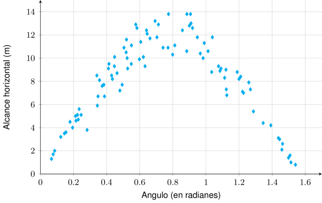

El comportamiento del alcance respecto al angulo es

## Answerlist

- lineal y con mayor dispersion cuanto mayor sea la inclinacion inicial.
- lineal y con mayor dispersion cuanto mayor sea el alcance del proyectil.
- no proporcional y con mayor dispersion cuanto mayor sea la inclinacion inicial.
- no proporcional y con mayor dispersion cuanto mayor sea el alcance del proyectil.

# Solution

Para analizar el comportamiento del alcance respecto al angulo, debemos observar dos aspectos clave en la grafica de dispersion:

**1. Tipo de relacion (lineal vs no proporcional):**

La relacion entre el angulo y el alcance sigue la ecuacion del movimiento de proyectiles:

$$R = \frac{v_0^2
\sin(2\theta)}{g}$$

Esta es una funcion senoidal, por lo tanto **no proporcional**. En la grafica se observa claramente una forma parabolica con un maximo aproximadamente en $\theta \approx 0.78$ radianes ($\approx 45°$).

**2. Patron de dispersion:**

Observando la grafica:

- En los extremos (angulos cercanos a 0 y 1.5 radianes): los puntos estan mas concentrados
- En la zona central (alcances mayores, alrededor de 10-13 m): los puntos muestran mayor variabilidad

Esto indica que **la dispersion es proporcional a el alcance del proyectil**, no a la inclinacion inicial. Fisicamente, esto tiene sentido porque los errores experimentales se amplifican en trayectorias mas largas.

**Conclusion:**

El comportamiento es **no proporcional** (forma parabolica) y **con mayor dispersion cuanto mayor sea el alcance del proyectil** (mayor variabilidad en valores altos de alcance).

## Answerlist

- **Falso**. La relacion no es lineal (es no proporcional) y la dispersion no depende de la inclinacion inicial sino de el alcance del proyectil.
- **Falso**. Aunque la dispersion si aumenta con el alcance del proyectil, la relacion NO es lineal.
- **Falso**. Si bien la relacion es no proporcional, la dispersion NO aumenta con la inclinacion inicial sino con el alcance del proyectil.
- **Verdadero**. La relacion es no proporcional (forma parabolica) y la dispersion aumenta proporcionalmente a el alcance del proyectil.

# Meta-information

exname: dispersion_alcance_proyectil_aleatorio_interpretacion_representacion_n2_v1 extype: schoice exsolution: 0001 exshuffle: TRUE exsection: Estadistica/Graficas de Dispersion